# Visualization of the Model: Categorical Predictors

## Introduction

- Last week, we discussed how to visualize the resulting model.

## Lecture Example Set Up

- Recall our example dataset of duck-related incidents,

```r
duck_incidents <- read_csv("https://raw.githubusercontent.com/samanthaseals/SDSII/refs/heads/main/files/data/lectures/W2_duck_incidents.csv") %>%
  mutate(loc_yard = if_else(location == "Backyard", 1, 0),
         loc_garage = if_else(location == "Garage", 1, 0),
         loc_kitchen = if_else(location == "Kitchen", 1, 0),
         loc_living = if_else(location == "Living Room", 1, 0))
duck_incidents %>% head()
```

| nephew | mischief_type | location | donald_present | donald_reaction | sugar_grams | damage_cost | loc_yard | loc_garage | loc_kitchen | loc_living |
| --- | --- | --- | --- | --- | --- | --- | --- | --- | --- | --- |
| Louie | Explosive | Kitchen | No | Yells | 58.0 | 1172.92 | 0 | 0 | 1 | 0 |
| Louie | Explosive | Living Room | No | Grounds | 75.2 | 696.66 | 0 | 0 | 0 | 1 |
| Huey | Explosive | Kitchen | No | Yells | 54.0 | 561.76 | 0 | 0 | 1 | 0 |
| Louie | Explosive | Kitchen | No | Laughs | 55.5 | 1020.26 | 0 | 0 | 1 | 0 |
| Huey | Mechanical | Backyard | Yes | Yells | 56.3 | 128.64 | 1 | 0 | 0 | 0 |
| Huey | Explosive | Backyard | No | Yells | 31.8 | 212.29 | 1 | 0 | 0 | 0 |

## Example 1: One Categorical Predictor

- Recall our example from the last lectures,

```r
m1 <- glm(damage_cost ~ location,
          data = duck_incidents)
tidy(m1, conf.int = TRUE)
```

| term | estimate | std.error | statistic | p.value | conf.low | conf.high |
| --- | --- | --- | --- | --- | --- | --- |
| (Intercept) | 202.77983 | 28.41515 | 7.136328 | 3.908222e-12 | 147.08716 | 258.4725 |
| locationGarage | 64.34182 | 42.00800 | 1.531656 | 1.263162e-01 | -17.99234 | 146.6760 |
| locationKitchen | 131.84687 | 41.02921 | 3.213488 | 1.406423e-03 | 51.43110 | 212.2626 |
| locationLiving Room | 58.69676 | 38.86972 | 1.510090 | 1.317287e-01 | -17.48649 | 134.8800 |

## Example 1: One Categorical Predictor

- This model only has categorical predictors that have no order to them.

$$\hat{\text{cost}} = 202.78 + 64.34 \text{ garage} + 131.85 \text{ kitchen} + 58.70 \text{ living}$$

- Because this is effectively a simple linear regression (one predictor with 4 levels - *location*), the way we visualized the model before does not make sense.
  - Why? We do not have a variable to put on the $x$-axis.
- Instead, we will use a different type of plot to visualize the results.
  - In this case, I would graph the predicted damage cost for each location and include error bars for the confidence intervals.
- First, we need to find the marginal means and the simultaneous confidence intervals.

## Side Note: Marginal Means & Simultaneous CI

- What are marginal means and simultaneous confidence intervals?
- Marginal means are the predicted means for each level of a categorical predictor, averaging (or “marginalizing”) over the other predictors in the model.
- Simultaneous confidence intervals are confidence intervals that *account for multiple comparisons*, ensuring that the overall confidence level is maintained across all intervals.
  - That is, we know that *together*, the condfidence intervals have an overall 95% confidence level.
- This means that the resulting CI will depend on the number of comparisons we are performing.
  - When using the Bonferroni correction, we only divide by the number of comparisons we are interested in.
  - The simultaneous CI accounts for all possible comparisons.

## Side Note: Marginal Means & Simultaneous CI (R)

- In R, we will use the `emmeans()` function from the `emmeans` package to calculate the marginal means.

```r
emm <- emmeans(model_name, ~ categorical_variable)
```

- Then, we use the `confint()` function to calculate the simultaneous confidence intervals.

```r
emm_ci <- confint(emm, adjust = "Sidak")
```

- Finally, we can create the dataset for graphing.

```r
conf_data <- as_tibble(emm_ci)
```

## Example 1: One Categorical Predictor

- In our example,

```r
emm <- emmeans(m1, ~ location)
emm_ci <- confint(emm, adjust = "Sidak")
graph <- as_tibble(emm_ci)
```

- Looking at the resulting data,

| Location | Average Cost | LCL | UCL |
| --- | --- | --- | --- |
| Backyard | 202.7798 | 131.7132 | 273.8465 |
| Garage | 267.1216 | 189.7416 | 344.5017 |
| Kitchen | 334.6267 | 260.6045 | 408.6489 |
| Living Room | 261.4766 | 195.1439 | 327.8093 |

## Graphing Means and Simultaneous CIs

- Now that our dataset has been created, we can construct the graph.

```r
graph %>% ggplot(aes(x = categorical_variable, y = emmean)) +
    geom_point() +
    geom_errorbar(aes(ymin = lower.CL, ymax = upper.CL), width = 0.2) +
    labs(x = "Categorical Label",
         y = "Outcome Label") +
    theme_bw()
```

## Example 1: One Categorical Predictor

- In our example,

```r
graph %>% ggplot(aes(x = location, y = emmean)) +
    geom_point() +
    geom_errorbar(aes(ymin = lower.CL, ymax = upper.CL), width = 0.2) +
    labs(x = "Location",
         y = "Average Damage Cost") +
    theme_bw()
```

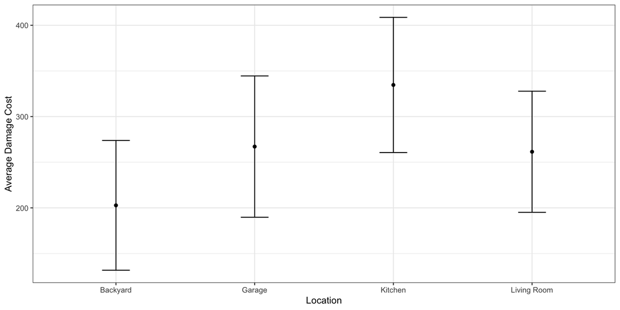

## Example 3: Mixing Continuous and Categorical Predictors

- Recall the model examining damage cost as a function of *location*, *nephew*, and *sugar_grams*.

```r
m5 <- glm(damage_cost ~ location + nephew + sugar_grams,
          data = duck_incidents)
tidy(m5, conf.int = TRUE)
```

| term | estimate | std.error | statistic | p.value | conf.low | conf.high |
| --- | --- | --- | --- | --- | --- | --- |
| (Intercept) | 62.162513 | 54.487731 | 1.14085340 | 2.545473e-01 | -44.6314773 | 168.956504 |
| locationGarage | 54.773465 | 39.776014 | 1.37704761 | 1.691930e-01 | -23.1860895 | 132.733019 |
| locationKitchen | 92.647154 | 40.607538 | 2.28152600 | 2.299101e-02 | 13.0578418 | 172.236466 |
| locationLiving Room | 58.373882 | 37.109392 | 1.57302181 | 1.164277e-01 | -14.3591888 | 131.106954 |
| nephewHuey | -0.899301 | 33.761747 | -0.02663669 | 9.787615e-01 | -67.0711099 | 65.272508 |
| nephewLouie | 198.792202 | 33.474865 | 5.93855135 | 5.817006e-09 | 133.1826732 | 264.401731 |
| sugar_grams | 1.835897 | 1.022077 | 1.79624167 | 7.313730e-02 | -0.1673368 | 3.839132 |

## Visualizing Models with Mixed Predictor Types

- Now we have a model with one continuous predictor and two categorical predictors.
- This means that we can return to our previous method of visualizing the model.
  - We will graph the predicted damage cost ($y$) as a function of sugar grams ($x$); our predicted values will depend on location and nephew.
- How do we include categorical predictors in this graph? There are two approaches:
  - Look at individual graphs for different categories.
  - Create different lines for specific categories.

## Example 3: Mixing Continuous and Categorical Predictors

- Our current model has both categorical and continuous predictors,

$$\begin{align*}
\hat{\text{cost}} = 62.16 &+ 54.77 \text{ garage} + 92.65 \text{ kitchen} + 58.37 \text{ living} \\
& - 0.90 \text{ Huey} + 198.79 \text{ Louie} \\
& + 1.84 \text{ sugar}
\end{align*}$$

- In our example,
  - We could create four graphs: one for each location with the lines defined by nephew.
  - We could create three graphs: one for each nephew with the lines defined by location.
  - We could create a single graph with lines defined by both location and nephew.
  - etc.

## Visualizing Models with Mixed Predictor Types

- Wait! There are multiple approaches!
- Which approach is appropriate?
  - It depends on the context of the problem and what comparisons are most relevant.
  - Note: I do not put a ton of effort on graphs when drafting them for collaborators. I will draft something basic for demonstration purposes and discussion.
    - e.g., maybe a graph for a single nephew or a single location, then ask which is preferred before I draft the graphs for the additional nephews or locations.
- For class credit: I am looking for competency in graphing. I am not looking for perfect graphs. Remember that we are *practicing* and cannot talk to our (hypothetical) collaborators in our projects.

## Creating Predicted Values with Categorical Predictors

- Recall how we defined our indicator variables for *nephew*,

| Nephew | $x_{\text{H}}$ | $x_{\text{D}}$ | $x_{\text{L}}$ |
| --- | --- | --- | --- |
| Huey | 1 | 0 | 0 |
| Dewey | 0 | 1 | 0 |
| Louie | 0 | 0 | 1 |

- That means, to create predicted values for specific nephews, we need to set the indicator variables accordingly.
  - e.g., for Huey, set $x_{\text{H}} = 1$, $x_{\text{D}} = 0$, and $x_{\text{L}} = 0$.
  - e.g., for Dewey, set $x_{\text{H}} = 0$, $x_{\text{D}} = 1$, and $x_{\text{L}} = 0$.
  - e.g., for Louie, set $x_{\text{H}} = 0$, $x_{\text{D}} = 0$, and $x_{\text{L}} = 1$.
- Remember, we only plug in for two of the newphews in the model (the third is the reference category).

## Creating Predicted Values with Categorical Predictors

- We will take the same approach for *location*.

| Location | $x_{\text{B}}$ | $x_{\text{G}}$ | $x_{\text{K}}$ | $x_{\text{L}}$ |
| --- | --- | --- | --- | --- |
| Backyard | 1 | 0 | 0 | 0 |
| Garage | 0 | 1 | 0 | 0 |
| Kitchen | 0 | 0 | 1 | 0 |
| Living Room | 0 | 0 | 0 | 1 |

- Then, the indicators will be plugged in as follows,
  - e.g., for backyard, set $x_{\text{B}} = 1$, $x_{\text{G}} = 0$, $x_{\text{K}} = 0$, and $x_{\text{L}} = 0$.
  - e.g., for garage, set $x_{\text{B}} = 0$, $x_{\text{G}} = 1$, $x_{\text{K}} = 0$, and $x_{\text{L}} = 0$.
  - e.g., for kitchen, set $x_{\text{B}} = 0$, $x_{\text{G}} = 0$, $x_{\text{K}} = 1$, and $x_{\text{L}} = 0$.
  - e.g., for living room, set set $x_{\text{B}} = 0$, $x_{\text{G}} = 0$, $x_{\text{K}} = 0$, and $x_{\text{L}} = 1$.

## Example 3: Mixing Continuous and Categorical Predictors

- Back to the current model,

$$\begin{align*}
\hat{\text{cost}} = 62.16 &+ 54.77 \text{ garage} + 92.65 \text{ kitchen} + 58.37 \text{ living} \\
& - 0.90 \text{ Huey} + 198.79 \text{ Louie} \\
& + 1.84 \text{ sugar}
\end{align*}$$

## Example 3: Mixing Continuous and Categorical Predictors

- Defining our predicted values, we will need one for each location (because they are defining our lines) and for each nephew (because they are defining our graphs).